# DataFest

Albert Sun and Ben Wallace

4/9/2020

```r
library(dplyr)
```

```r
library(ggplot2)
library(patchwork)
library(twitteR)
library(lubridate)
library(rvest)
library(sf)
library(tidycensus)
library(mapview)
library(broom)
library(tidyverse)       # Tidyverse for Tidy Data
library(readxl)
library(tigris)
library(sf)
library(viridis)
library(stringr)
library(maps)
counties <- read.csv("datafiles/us-counties.csv")
states <- read.csv("datafiles/us-states.csv")
measures <- read.csv("datafiles/statedata.csv")
global_measures <- read.csv("datafiles/ACAPSGlobalResponse.csv")
covidapproval <- read.csv("datafiles/Covidapproval_Population.csv")
jails <- read.csv("datafiles/Jails.finalstates.csv")
```

```r
toptencounties <- counties %>%
  filter(date == "2020-04-08") %>%
  arrange(desc(cases))

toptencounties <- toptencounties[1:10,]

toptenstates <- states %>%
  filter(date == "2020-04-08") %>%
  arrange(desc(cases))

toptenstates <- toptenstates[1:10,]
```

# NY State and County Date

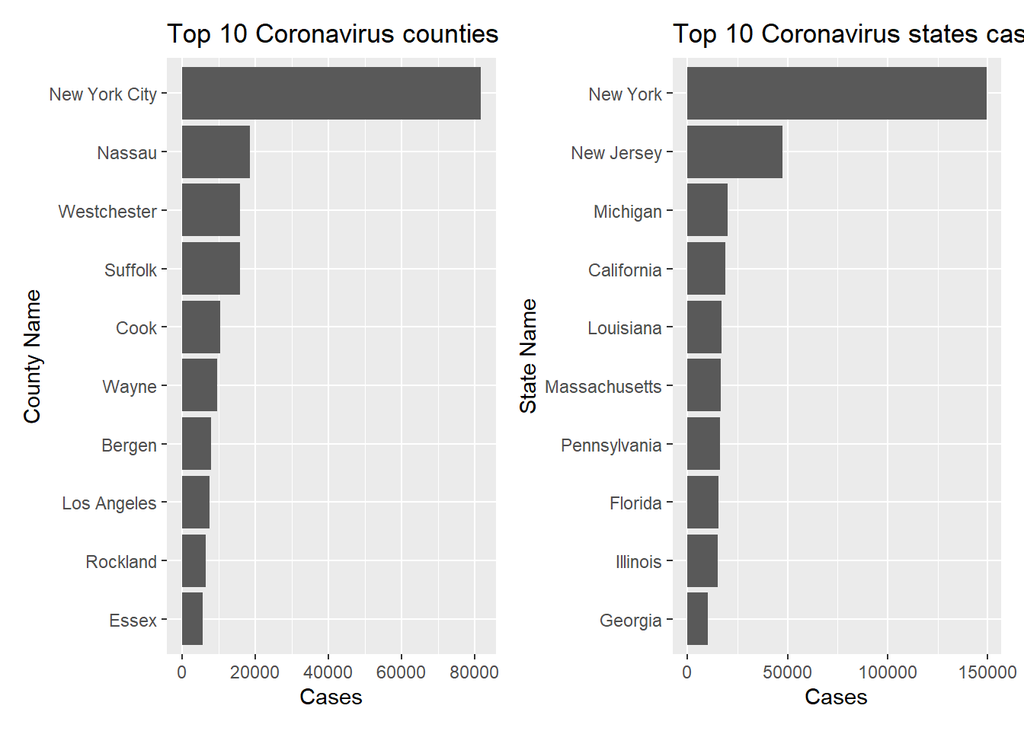

```r
p1 <- ggplot(data = toptencounties, mapping = aes(x = reorder(county, cases),
                                                  y = cases),
             fill=if_else(County=="New York")) +
  geom_bar(stat = "identity") +
  labs(title = "Top 10 Coronavirus counties cases",
       y = "Cases", x = "County Name") +
  coord_flip()

p2 <- ggplot(data = toptenstates, mapping = aes(x = reorder(state, cases),
                                                y = cases)) +
  geom_bar(stat = "identity") +
  labs(title = "Top 10 Coronavirus states cases",
       y = "Cases", x = "State Name") +
  coord_flip()

p1 + p2
```

# Global Measures

```r
global_measures %>%
  filter(CATEGORY == "Social distancing") %>%
  count(COUNTRY) %>%
  arrange(-n)
```

```
## # A tibble: 173 x 2
##    COUNTRY               n
##    <fct>             <int>
##  1 Ireland              17
##  2 Hungary              14
##  3 Australia            13
##  4 Lithuania            12
##  5 Yemen                12
##  6 Barbados             11
##  7 Czech Republic       11
##  8 Equatorial Guinea    11
##  9 Estonia              11
## 10 Ethiopia             11
## # ... with 163 more rows
```

```r
first_measures <- global_measures %>%
  filter(CATEGORY == "Social distancing") %>%
  mutate(date = dmy(DATE_IMPLEMENTED)) %>%
  arrange(COUNTRY, date) %>%
  select(COUNTRY, date) %>%
  group_by(COUNTRY) %>%
  slice(1) %>%
  ungroup() %>%
  select(COUNTRY, date) %>%
  arrange(date) %>%
  slice(-11:-n()-10)
```

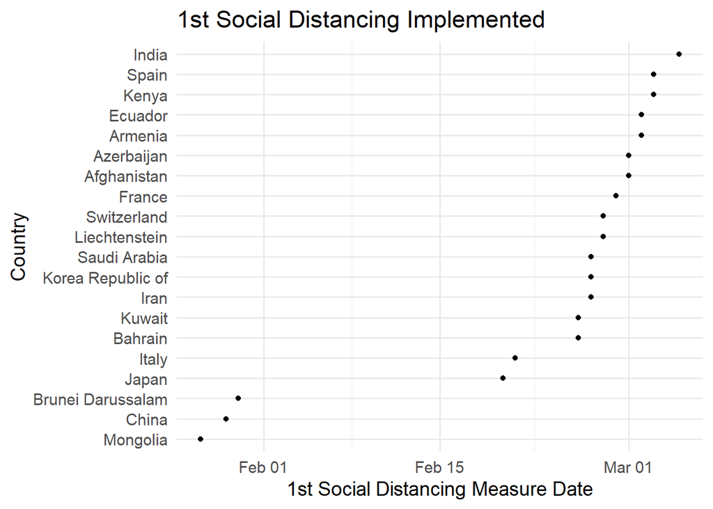

```r
ggplot(first_measures, mapping = aes(x = reorder(COUNTRY, date), y = date)) +
  geom_point() + coord_flip() +
  labs(y = "1st Social Distancing Measure Date", x = "Country",
       title = "1st Social Distancing Implemented") +
  theme_minimal(base_size = 14)
```

# Jail Data

```r
jails %>%
  summarise(n(), n_distinct(State_Abbrev))
```

```
##   n() n_distinct(State_Abbrev)
## 1 333                       27
```

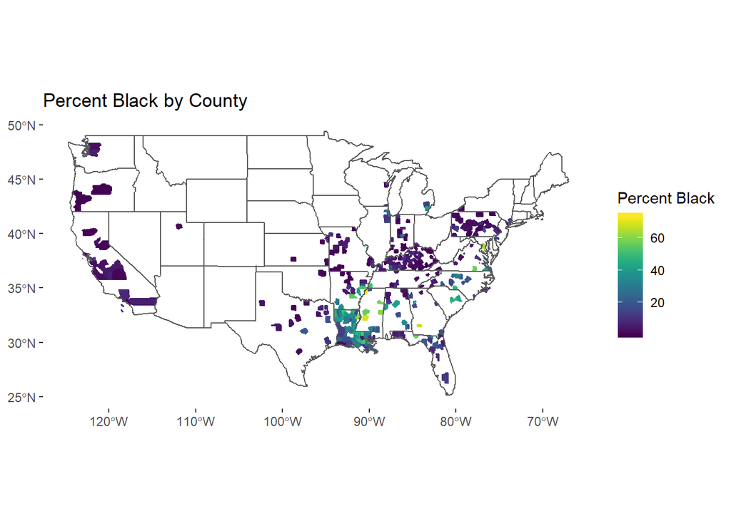

```r
# P005003 = White
# P005004 = Black
# P005004 = Hispanic
# P005005 = AmInd/AK
# P005006 = Asian
# P001001 = Population Total

black <- c("P005004")

blackgeo <- get_decennial(geography = "county", variables = black, year = 2010, summary_var = "P001001", geometry = TRUE) %>%
  mutate(pctblack = 100 * (value / summary_value))
jails$CountyState = as.character(jails$CountyState)
blackgeo$NAME = str_replace(blackgeo$NAME, " County", "")
blackgeo$NAME = str_replace(blackgeo$NAME, " Parish", "")


stategeo <- st_as_sf(map("state", plot = FALSE, fill = TRUE))

jails <- left_join(jails, blackgeo, by = c("CountyState" = "NAME"))

jails <- jails %>%
  drop_na()

jails$geom = jails$geometry

ggplot() +
  geom_sf(aes(geometry = geom, fill = pctblack, color = pctblack), data = jails) +
  labs(title = "Percent Black by County",
       fill = "Percent Black",
       color = "Percent Black") +
  scale_fill_viridis(option = "viridis") +
  scale_color_viridis(option = "viridis") +
  geom_sf(data = stategeo, fill = NA) +
  theme(panel.background = element_rect(fill = "white"))
```

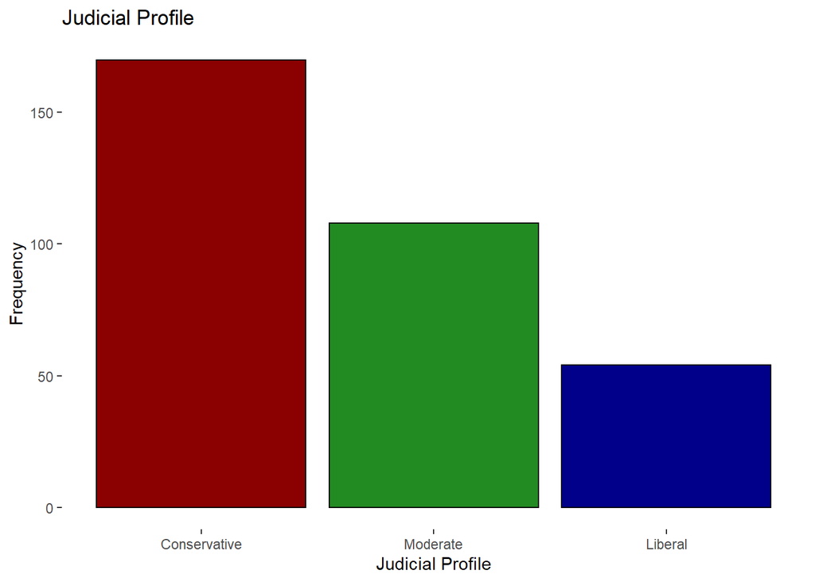

```r
### Mapping Jurisdictions

jails$Jurisdiction_Profile = recode_factor(jails$Jurisdiction_Profile, "R" = "Conservative", "M" = "Moderate", "B" = "Liberal")

ggplot(data = jails, aes(x = Jurisdiction_Profile)) +
  geom_bar(aes(fill = Jurisdiction_Profile), color = "black") +
  scale_fill_manual(values = c("DarkRed", "ForestGreen", "Blue4")) +
  labs(x = "Judicial Profile",
       y = "Frequency",
       title = "Judicial Profile") +
  theme(legend.position = "none") +
  theme(panel.background = element_rect(fill = "white"))
```

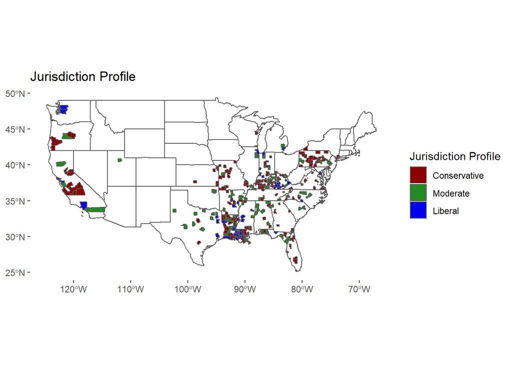

```r
ggplot() +
  geom_sf(aes(geometry = geom, fill = Jurisdiction_Profile), data = jails) +
  labs(title = "Jurisdiction Profile",
       fill = "Jurisdiction Profile") +
  geom_sf(data = stategeo, fill = NA) +
  scale_fill_manual(values = c("darkred", "forestgreen", "blue2")) +
  theme(panel.background = element_rect(fill = "white"))
```

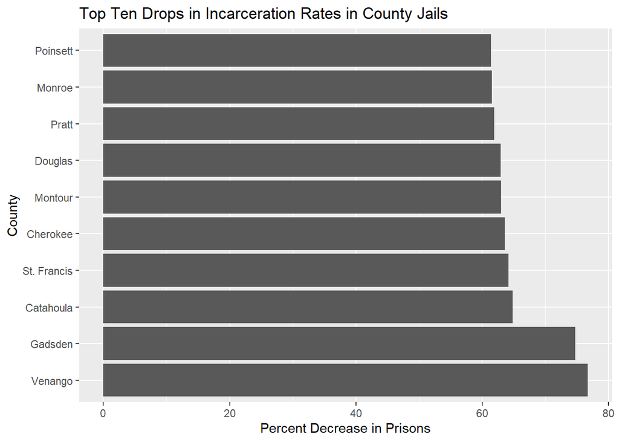

```r
topTenJails <- jails %>%
  arrange(Percent_Change) %>%
  select(State, County, Percent_Change) %>%
  slice(1:10)

ggplot(data = topTenJails, mapping = aes(x = reorder(County, Percent_Change),
                                         y = abs(Percent_Change) * 100)) +
  geom_bar(stat = "identity") +
  coord_flip() +
  labs(x = "County", y = "Percent Decrease in Prisons",
       title = "Top Ten Drops in Incarceration Rates in County Jails")
```

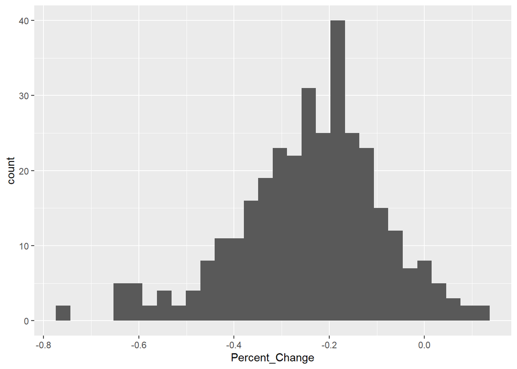

```r
ggplot(data = jails, aes(x = Percent_Change)) +
  geom_histogram()
```

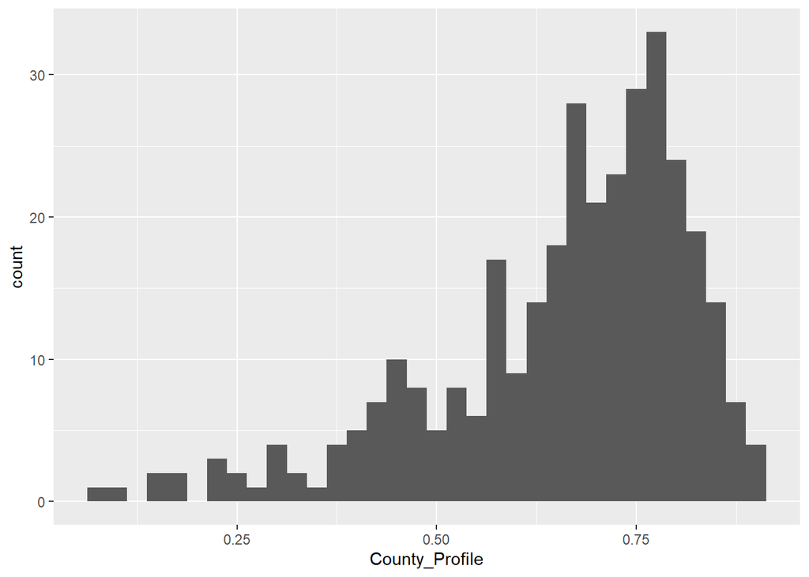

```r
ggplot(data = jails, aes(x = County_Profile)) +
  geom_histogram(binwidth = .025)
```

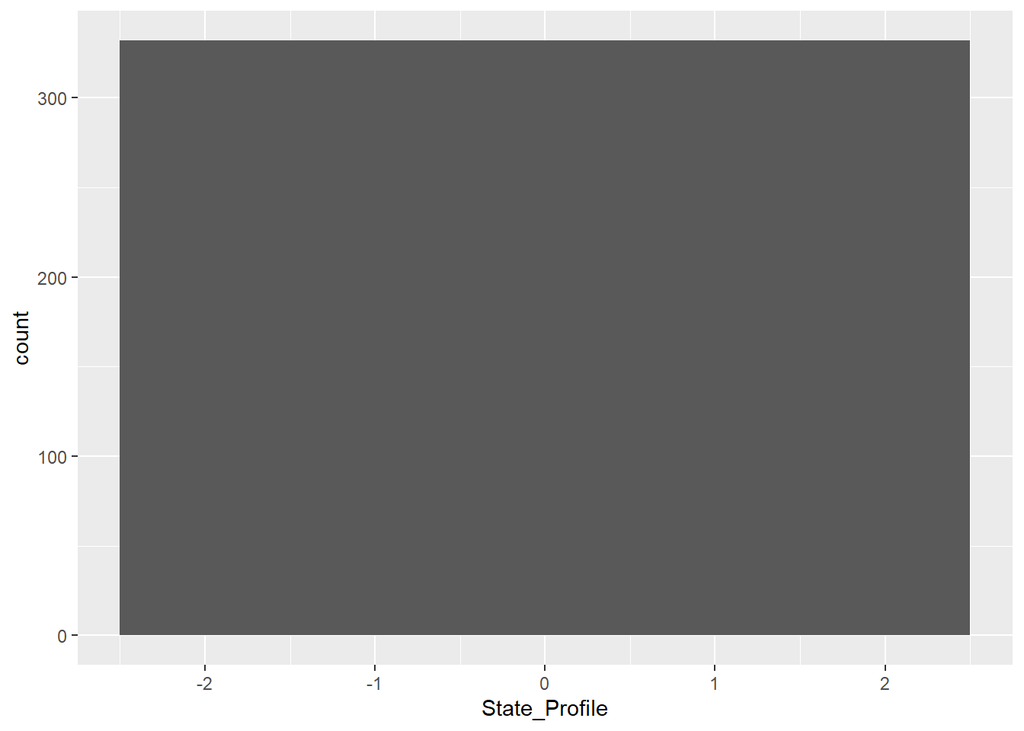

```r
ggplot(data = jails, aes(x = State_Profile)) +
geom_histogram(binwidth = 5)
```

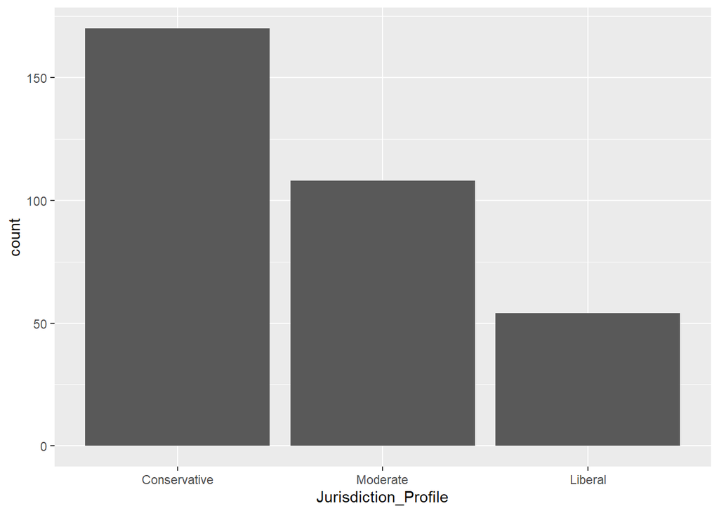

```r
ggplot(data = jails, aes(x = Jurisdiction_Profile)) +
  geom_bar()
```

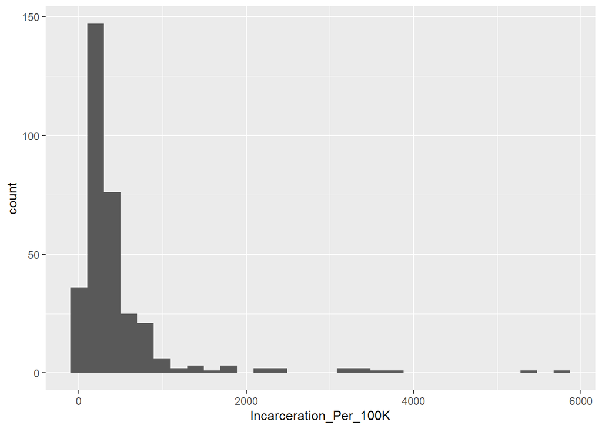

```r
ggplot(data = jails, aes(x = Incarceration_Per_100K)) +
geom_histogram()
```

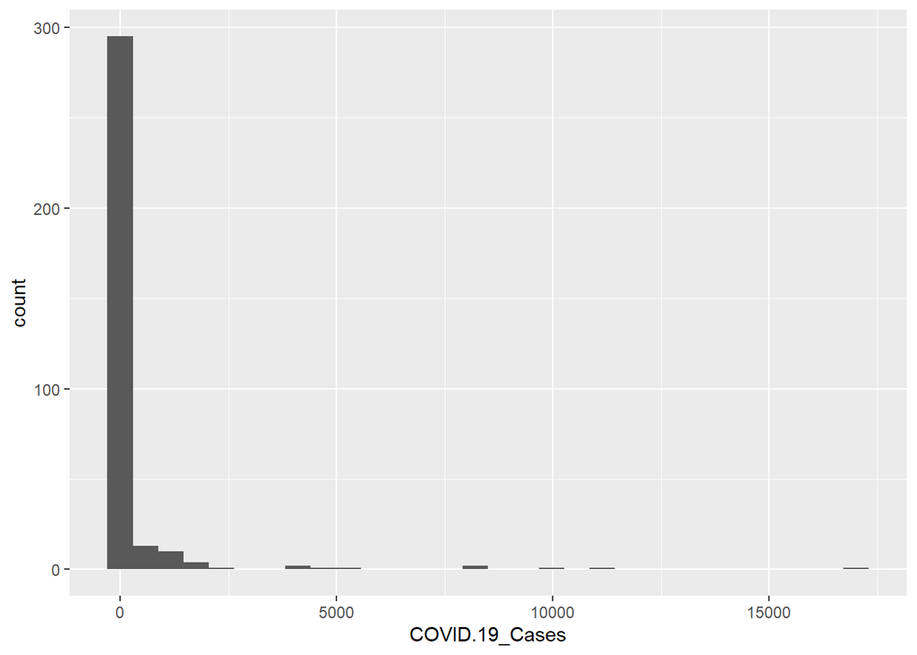

```r
ggplot(data = jails, aes(x = COVID.19_Cases)) +
  geom_histogram()
```

```r
jails %>%
  summarise(mean = mean(COVID.19_Cases), ## Also log transform this?
            median = median(COVID.19_Cases)
  )
```

```
##       mean median
## 1 329.6837     18
```

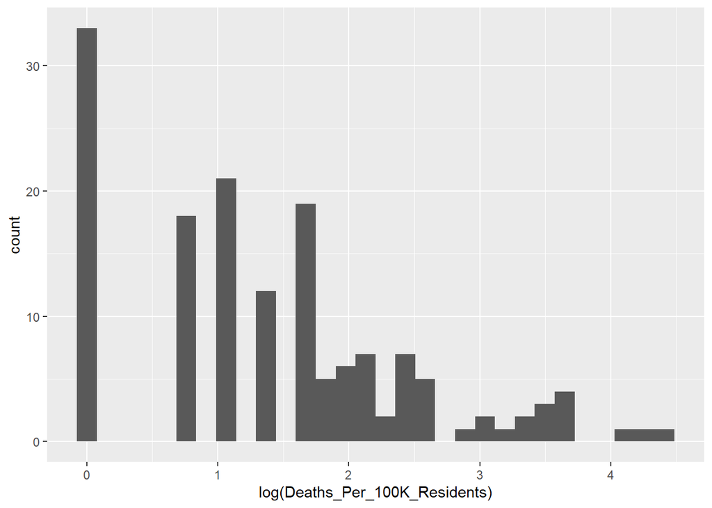

```r
ggplot(data = jails, aes(x = log(Deaths_Per_100K_Residents))) + ### Log transform variable?
  geom_histogram()
```

```r
lm_full <- lm(Percent_Change ~ County_Profile + State_Profile +
                Jurisdiction_Profile, data = jails)

lm <- step(lm_full, direction = "backward", trace=FALSE)

tidy(lm) %>%
  select(term, estimate, p.value)
```

```
## # A tibble: 3 x 3
##   term                         estimate  p.value
##   <chr>                           <dbl>    <dbl>
## 1 (Intercept)                   -0.253  5.23e-65
## 2 Jurisdiction_ProfileModerate   0.0113 5.47e- 1
## 3 Jurisdiction_ProfileLiberal    0.0498 3.75e- 2
```

#^Stepwise function uses similar strategy to adjusted R squared to find the best #fit model with constrinas in mind. Here, it finds that Jurisdiction_Profile is #the most important relationship

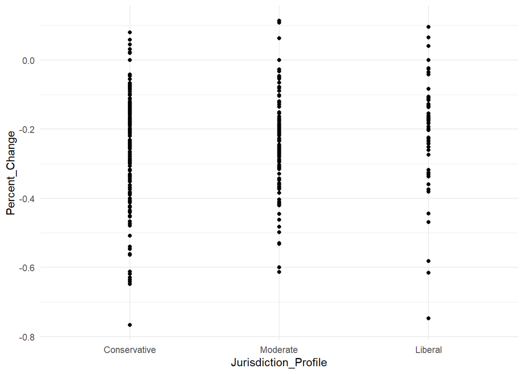

```r
ggplot(data = jails, aes(x = Jurisdiction_Profile, y = Percent_Change)) +
  geom_point() +
  geom_smooth(method = "lm", se = FALSE) +
  theme_minimal()
```

This graph doesn’t look very legit…

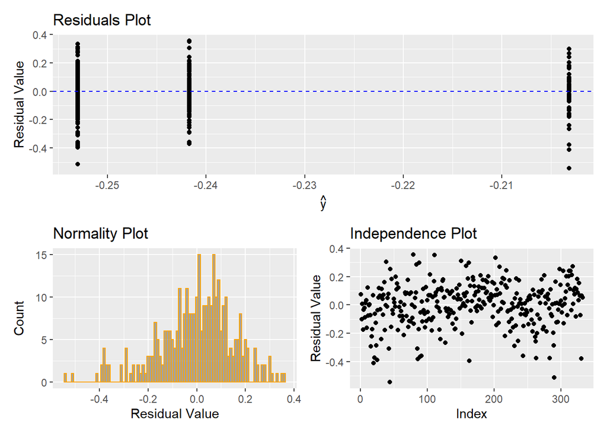

```r
plot_diagnostic <- function(x, data) {

  plot_residuals <- augment(x) %>%
    ggplot(aes(x = .fitted, y = .resid)) +
    geom_point() +
    geom_hline(yintercept = 0, color = "blue", lty = 2) +
    labs(x = expression(hat(y)), y = "Residual Value",
         title = "Residuals Plot")

  plot_normality <- augment(x) %>%
    ggplot(aes(x = .resid)) +
    geom_histogram(binwidth = .01, alpha = .5, color = "orange") +
    labs(x = "Residual Value", y = "Count", title = "Normality Plot")

  plot_independence <- augment(x) %>%
    ggplot(aes(x = 1:nrow(data), y = .resid)) +
    geom_point() +
    labs(x = "Index", y = "Residual Value", title = "Independence Plot")

  plot_residuals / (plot_normality + plot_independence)
}

plot_diagnostic(lm, jails)
```

Conditions of Linearity:

Condition 1: We must verify that observations are independent. In this case, there doesn’t seem to be a pattern in the residual scatter plot, so the observations are independent.

Conditions 2 & 4: We must verify that the distribution of residuals is around 0 and has constant variance. The variance plot shows that the distribution of residuals is centered around 0 and has constant variance throughout.

Condition 3: We must verify the normality of residuals. The residual histogram displays a normal distribution of residual values, so we have verified the normality of residuals.

```r
model <- lm(Percent_Change ~ County_Profile + State_Profile + Jurisdiction_Profile + Cases_Per_100K_Residents + COVID.19_Deaths, data = jails)

tidy(model)
```

```
## # A tibble: 7 x 5
##   term                           estimate std.error statistic   p.value
##   <chr>                             <dbl>     <dbl>     <dbl>     <dbl>
## 1 (Intercept)                  -0.251     0.0630       -3.99  0.0000814
## 2 County_Profile                0.0368    0.0679        0.542 0.588
## 3 State_Profile                -0.0542    0.123        -0.439 0.661
## 4 Jurisdiction_ProfileModerate  0.0135    0.0193        0.701 0.484
## 5 Jurisdiction_ProfileLiberal   0.0548    0.0257        2.14  0.0335
## 6 Cases_Per_100K_Residents      0.0000751 0.0000571     1.31  0.190
## 7 COVID.19_Deaths              -0.000327  0.000210     -1.55  0.121
```

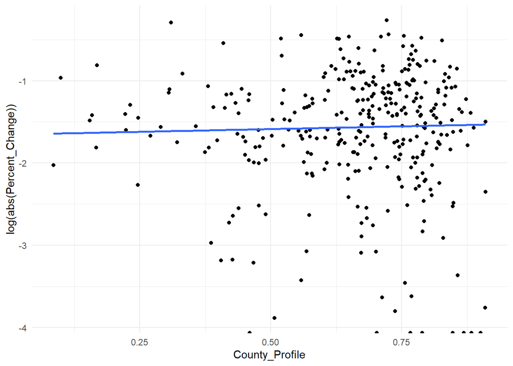

```r
ggplot(data = jails, aes(x = County_Profile, y = log(abs(Percent_Change)))) +
  geom_point() +
  geom_smooth(method = "lm", se = FALSE) +
  theme_minimal()
```

Doesn’t seem very legit either…

```r
model_aug <- augment(model) %>%
  mutate(obs_num = row_number())
```

```r
leverage_threshold <- 2*(5 + 1)/nrow(model_aug)

high_leverage <- model_aug %>%
  mutate(high_lev = .hat > leverage_threshold) %>%
  select(high_lev, obs_num)
```

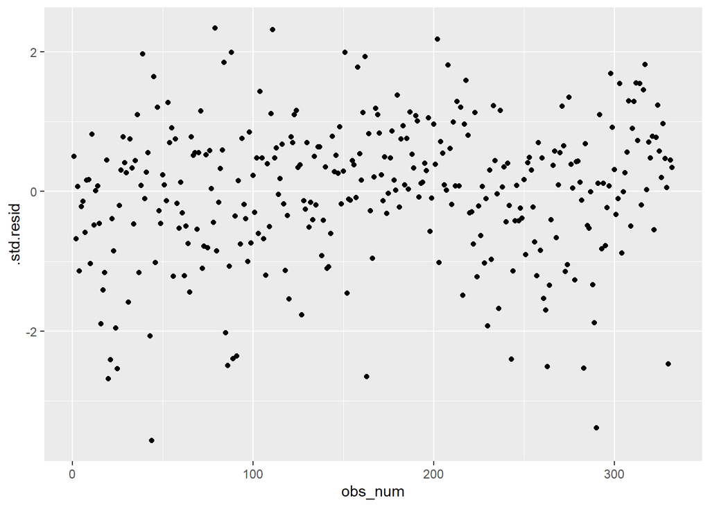

```r
ggplot(data = model_aug, aes(x = obs_num, y = .std.resid)) +
  geom_point()
```

```r
model_aug %>%
  summarise(min = min(.std.resid),
            max = max(.std.resid),
            mean = mean(.std.resid),
            median = median(.std.resid))
```

```
## # A tibble: 1 x 4
##     min   max      mean median
##   <dbl> <dbl>     <dbl>  <dbl>
## 1 -3.57  2.34 0.0000441 0.0945
```

```r
high_sdresid <- model_aug %>%
  mutate(high_sd = abs(.std.resid) > 2) %>%
  select(obs_num, high_sd)
```

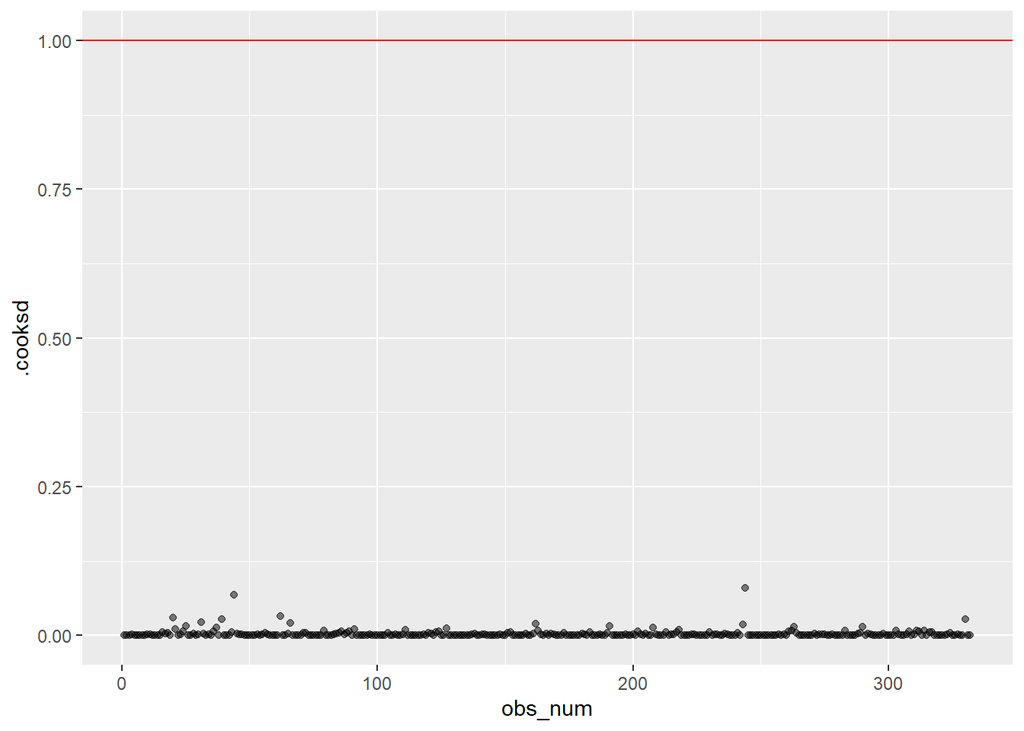

```r
ggplot(data = model_aug, aes(x = obs_num, y = .cooksd)) +
  geom_point(alpha = 0.5) +
  geom_hline(yintercept = 1, color = "red")
```

```r
high_cookdist <- model_aug %>%
  mutate(high_cook = .cooksd > 1) %>%
  select(obs_num, high_cook)
```

```r
unusual <- bind_cols(high_leverage, high_sdresid, high_cookdist)

unusual <- unusual %>%
  select(high_lev, high_sd, high_cook)
```

Also look into the cases with high std. residuals to see if they should be removed.

```r
jails <- jails %>%
  mutate(obs_num =  1:n()) %>%
  filter(obs_num != 245)
```

```r
model2 <- lm(Percent_Change ~ County_Profile + State_Profile + Jurisdiction_Profile + COVID.19_Cases + pctblack + pctblack*Jurisdiction_Profile, data = jails)

tidy(model2)
```

```
## # A tibble: 9 x 5
##   term                                   estimate  std.error statistic   p.value
##   <chr>                                     <dbl>      <dbl>     <dbl>     <dbl>
## 1 (Intercept)                         -0.296      0.0645        -4.59    6.50e-6
## 2 County_Profile                       0.163      0.0816         2.00    4.58e-2
## 3 State_Profile                       -0.176      0.129         -1.36    1.75e-1
## 4 Jurisdiction_ProfileModerate         0.0175     0.0249         0.705   4.81e-1
## 5 Jurisdiction_ProfileLiberal          0.0804     0.0349         2.31    2.17e-2
## 6 COVID.19_Cases                      -0.00000327 0.00000623    -0.525   6.00e-1
## 7 pctblack                             0.00278    0.000986       2.82    5.17e-3
## 8 Jurisdiction_ProfileModerate:pctbl~ -0.000274   0.00133       -0.207   8.36e-1
## 9 Jurisdiction_ProfileLiberal:pctbla~ -0.00189    0.00129       -1.46    1.44e-1
```

```r
model2_aug <- augment(model2)

model2_aug <- model2_aug%>%
  mutate(obs_num = c(1:n()))

step_model2 <- step(model2, direction = "backward", trace=FALSE)

step_model2
```

```
##
## Call:
## lm(formula = Percent_Change ~ County_Profile + pctblack, data = jails)
##
## Coefficients:
##    (Intercept)  County_Profile        pctblack
##      -0.338383        0.106043        0.001971
```

step wise regression (*step function)

```r
summary(step_model2)
```

```
##
## Call:
## lm(formula = Percent_Change ~ County_Profile + pctblack, data = jails)
##
## Residuals:
##      Min       1Q   Median       3Q      Max
## -0.55137 -0.08585  0.01870  0.09208  0.37185
##
## Coefficients:
##                  Estimate Std. Error t value Pr(>|t|)
## (Intercept)    -0.3383834  0.0457223  -7.401 1.15e-12 ***
## County_Profile  0.1060427  0.0606980   1.747  0.08156 .
## pctblack        0.0019712  0.0005951   3.313  0.00103 **
## ---
## Signif. codes:  0 '***' 0.001 '**' 0.01 '*' 0.05 '.' 0.1 ' ' 1
##
## Residual standard error: 0.1515 on 328 degrees of freedom
## Multiple R-squared:  0.03237,    Adjusted R-squared:  0.02647
## F-statistic: 5.487 on 2 and 328 DF,  p-value: 0.004531
```

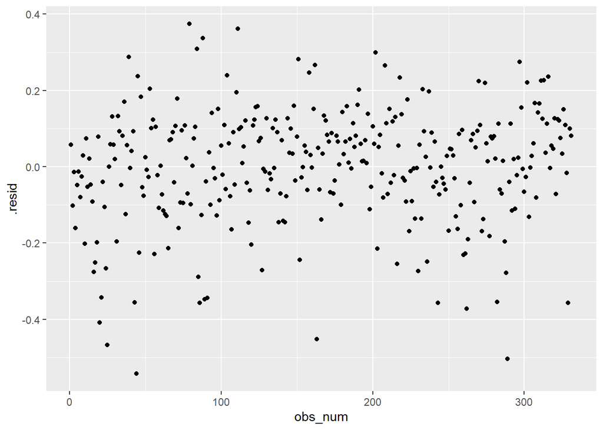

```r
ggplot(data = model2_aug, aes(x = obs_num, y = .resid)) +
  geom_point()
```